# The RNA Centric Analysis System Report

Bora Uyar, Dilmurat Yusuf, Ricardo Wurmus, Altuna Akalin

2016-04-13

# 1 Introduction

RNA Centric Annotation System (RCAS) automatically generates dynamic annotations for custom input files that contain transcriptomic target regions. High-throughput sequencing (HTS) has brought a profound impact on biological research at various levels. At the level of transcriptome, various HTS methods have been applied to study different aspects of the complete set of transcripts that are produced by the genome. On such method is cross-linking immunoprecipitation-high-throughput sequencing (CLIP-Seq) that is used to study RNA binding sites for a protein of interest on a genome-wide scale, thereby increasing the understanding of post-transcriptional regulatory networks. To mitigate the challenge posed by big data generated by HTS methods, automatic solution, such RCAS, is required to to facilitate biological discovery from taget regions located by methods such as Clip-Seq. RCAS automatically provides dynamic annotations for custom input files that contain transcriptomic target regions. Provided with target regions in [BED](http://www.ensembl.org/info/website/upload/bed.html) format( and annotation references in [GTF](http://www.ensembl.org/info/website/upload/gff.html) format, RCAS automatically summarizes annotated features that overlap with targets, and perform enrichment analysis of motifs, Gene Ontology (GO) terms and gene set. The summary of annotated features consists of intuitive reports in terms of distributions of gene types, genomic features, gene names and coverage profiles. Motif discovery is also one key component of RCAS automatic system. RCAS can provide users list of motifs that are enriched comparing with background sequences. In addition, RCAS generates lists of enriched gene sets and functions to shed light on the functional aspects of target regions. The final report of RCAS consists of high-quality dynamic figures and tables, which are readily applicable for publications or other academic usage.

# 2 Data input

RCAS requires inputs of a BED file and a GTF file. The BED file should contain coordinates/intervals of target transcriptomic regions which are located via transcriptomics methods such as Clip-Seq. The GTF file should provide reference annotation. The usual source of GTF files are [ENSEMBLE](http://www.ensembl.org/info/data/ftp/index.html).

For this vignette. to demonstrate RCAS functionality, we provide sample BED and GTF data via RCAS library, which can be imported using a common R function, data(). To import custom BED and GTF files, user should execute two RCAS functions called importBed() and importGtf().

## 2.1 Importing sample data

```r
library(RCAS)
data(queryRegions) #sample queryRegions in BED format()
data(gff)          #sample GFF file
```

## 2.2 Importing custom data

To use importBed() and importGtf(), the user should provide file paths to the respective BED file and GTF file. To reduce memory usage and time consumption, we advise user to set `sampleN=10000` to avoid huge input of intervals.

Before running following codes in your R interpreter, please remove `#` comment sign.

```r
#library(RCAS)
#queryRegions <- importBed(filePath = BED_file, sampleN = 10000)
#gff <- importGtf(filePath = GFF_file)
```

# 3 Summarizing Overlaps of Query Regions with Genomic Annotation Features

## 3.1 Querying the annotation file

```r
overlaps <- queryGff(queryRegions = queryRegions, gff = gff)
#data.table is used to do quick summary operations
overlaps.dt <- data.table(as.data.frame(overlaps))
```

### 3.1.1 Finding targeted gene types

To find out the distribution of the query regions across gene types:

```r
biotype_col <- grep('biotype', colnames(overlaps.dt), value = T)
df <- overlaps.dt[,length(unique(overlappingQuery)), by = biotype_col]
colnames(df) <- c("feature", "count")
df$percent <- round(df$count / length(queryRegions) * 100, 1)
df <- df[order(count, decreasing = TRUE)]
p <- plot_ly(data = df,
             type = "bar",
             x = feature,
             y = percent,
             text = paste("count:", count), color=feature)
layout(p = p,
       margin = list(l=100, r=100, b=150),
       xaxis = list(showticklabels = TRUE,  tickangle = 90),
       yaxis = list(title = paste("percentage of query regions,",
                                  "n =", length(queryRegions))))
```

[interactive chart not shown]

### 3.1.2 Distribution of query regions across chromosomes

To find out the distribution of the query regions across chromosomes:

```r
df <- overlaps.dt[,length(unique(overlappingQuery)), by = c('seqnames', 'type')]
colnames(df) <- c('seqnames', 'type', 'count')
df <- df[order(seqnames)]
p <- plot_ly(data = df,
             type = "bar",
             x = seqnames,
             y = count,
             text = paste("count:", count),
             color = type)
layout(p = p,
       margin = list(b=150),
       xaxis = list(showticklabels = TRUE,  tickangle = 90),
       yaxis = list(title = paste("Number of query regions,",
                                  "n =", length(queryRegions)
                                  )
                    )
       )
```

[interactive chart not shown]

## 3.2 Extending the annotation feature space

GTF files contain some annotation features (e.g. exons, transcripts) that are usually explicitly defined, however, some gene features such as introns, exon-intron boundaries, promoter regions are only implicitly defined. Such implicity features can be extracted from a GTF file using makeTxDb family of functions from the GenomicFeatures library.

First we create a list of GRanges objects, where each list element contains all the available coordinates of gene features such as transcripts, exons, introns, 5’/3’ UTRs, exon-intron boundaries, and promoter regions.

```r
txdbFeatures <- getTxdbFeaturesFromGff(gff)
```

### 3.2.1 Plotting overlap counts between query regions and gene features

To have a global overview of the distribution of query regions across gene features, we can use the summarizeQueryRegions function.

```r
summary <- summarizeQueryRegions(queryRegions = queryRegions,
                                 txdbFeatures = txdbFeatures)

df <- data.frame(summary)
df$percent <- round((df$count / length(queryRegions)), 3) * 100
p <- plot_ly( data = df,
              x = rownames(df),
              y = percent,
              type = 'bar',
              text = paste("count:", count),
              color = rownames(df)
              )
layout(p = p,
       xaxis = list(title = 'features'),
       yaxis = list(title = paste("percentage of query regions,",
                                  "n =", length(queryRegions)
                                  )
                    ),
       margin = list(b = 150, r = 50)
       )
```

[interactive chart not shown]

### 3.2.2 Obtaining a table of overlap counts between query regions and genes

To find out which genes overlap with how many queries and categorise overlaps by gene features; we use getTargetedGenesTable function, which returns a data.frame object. Then we use datatable function from ‘DT’ library to print an interactive table of genes that overlap query Regions.

```r
dt = getTargetedGenesTable(queryRegions = queryRegions,
                           txdbFeatures = txdbFeatures)
datatable(data = dt[order(transcripts, decreasing = T)][1:500],
          extensions = 'FixedColumns',
          options = list(
            dom = 't',
            scrollX = TRUE,
            scrollCollapse = TRUE
            )
          )
```

|  | tx_name | transcripts | exons | promoters | fiveUTRs | introns | exonIntronBoundaries | cds | threeUTRs |
| --- | --- | --- | --- | --- | --- | --- | --- | --- | --- |
| 1 | ENST00000317713 | 33 | 28 | 0 | 0 | 5 | 19 | 24 | 4 |
| 2 | ENST00000361689 | 33 | 28 | 0 | 0 | 5 | 19 | 24 | 4 |
| 3 | ENST00000372915 | 33 | 28 | 0 | 0 | 5 | 19 | 24 | 4 |
| 4 | ENST00000539005 | 33 | 28 | 0 | 0 | 5 | 19 | 24 | 4 |
| 5 | ENST00000545844 | 33 | 28 | 0 | 0 | 5 | 19 | 24 | 4 |
| 6 | ENST00000564288 | 33 | 28 | 0 | 0 | 5 | 19 | 24 | 4 |
| 7 | ENST00000567887 | 33 | 28 | 0 | 0 | 5 | 19 | 24 | 4 |
| 8 | ENST00000372925 | 28 | 23 | 0 | 0 | 5 | 14 | 19 | 4 |
| 9 | ENST00000289893 | 27 | 22 | 0 | 0 | 5 | 13 | 18 | 4 |
| 10 | ENST00000367142 | 14 | 14 | 0 | 0 | 0 | 2 | 3 | 12 |

[output cut: 490 more lines]

### 3.2.3 Profiling the coverage of query regions across gene features

#### 3.2.3.1 Coverage profile of query regions for 3’ UTRs

Coverage profiles can be obtained for a single type of gene feature or a list of gene features. Here we demonstrate how to get coverage profile of query regions across 3’UTRs. It might be a good idea to use sampleN parameter to randomly downsample the target regions to speed up the calculations.

```r
cov <- calculateCoverageProfile(queryRegions = queryRegions,
                               targetRegions = txdbFeatures$threeUTRs,
                               sampleN = 10000)

p <- plot_ly(cov, x = bins, y = coverage)
p %>%   add_trace(y = fitted(loess(coverage ~ as.numeric(bins)))) %>%
layout(title = paste("Coverage along 3'UTRs (5' -> 3' direction)", sep = " "),
       showlegend = FALSE,
       margin = list(l = 50, r = 50, b = 50, t = 50))
```

[interactive chart not shown]

#### 3.2.3.2 Coverage profile of query regions for all gene features

Coverage profiles can be obtained for a single type of gene feature or a list of gene features. Here we demonstrate how to get coverage profile of query regions across all available gene features. It might be a good idea to use sampleN parameter to randomly downsample the target regions to speed up the calculations.

```r
covList <- calculateCoverageProfileList(queryRegions = queryRegions,
                                       targetRegionsList = txdbFeatures,
                                       sampleN = 10000)

df <- do.call('cbind', covList)
df <- df[,!grepl(colnames(df), pattern = '*.bins')]
df$bins <- c(1:100)
colnames(df) <- gsub(pattern = ".coverage", replacement = "", x = colnames(df))
mdf <- reshape2::melt(df, id.vars = c('bins'))
colnames(mdf) <- c('bins', 'feature', 'coverage')
p = plot_ly(data = mdf, x = bins, y = coverage, color = feature)
layout(p)
```

[interactive chart not shown]

# 4 Motif Analysis using motifRG

## 4.1 Calculating enriched motifs

With the RCAS package, a motif analysis is also possible. RCAS uses motifRG library to find enriched motifs among the query regions.

```r
motifResults <- runMotifRG(queryRegions = queryRegions,
                           genomeVersion = 'hg19',
                           motifN = 4)
```

```
## extracting peak sequences from fasta..
## extracting background sequences from fasta..
## running motifRG...
## AGGAGA 8.163767e-06
##  Refine  AGGAGA 10.70133 : 10.98617 11.6152 10.68494 9.453721 11.25412 TRUE 463 176 451 167
## New motif:  AGGAGA
## match range  636
## [1] "Rescore"
## [1] "Finished Rescore"
## TGGAGA 4.495348e-07
## Skip pattern  TTTTTA TTTTAA
##  Refine  TGGAGA 12.52111 : 12.14565 11.57937 12.02418 12.32091 12.81758 TRUE 523 168 501 164
## New motif:  TGGAGA
## match range  687
## [1] "Rescore"
## [1] "Finished Rescore"
## TGAAGA 9.412336e-06
## Skip pattern  TTTTTT TTTTCT ATTTTT TTTAAA TTTCTT TGTTTT TTTTTC TTCTTT
##  Refine  TGAAGA 10.6737 : 10.24269 11.43595 12.1833 10.99673 10.06581 TRUE 530 220 504 215
## New motif:  TGAAGA
## match range  742
## [1] "Rescore"
## [1] "Finished Rescore"
## GGAAGA 5.046857e-06
## Skip pattern  TTTTAT TTTATT
##  Refine  GGAAGA 10.04982 : 10.44297 10.7668 9.736938 11.63925 10.17246 TRUE 462 187 436 182
## New motif:  GGAAGA
```

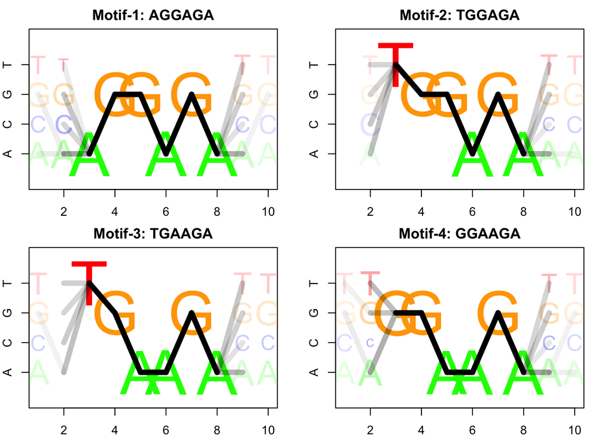

```r
par(mfrow = c(2,2), mar = c(2,2,2,2))
for (i in 1:length(motifResults$motifs)) {
  motifPattern <- motifResults$motifs[[i]]@pattern
  motifRG::plotMotif(match = motifResults$motifs[[i]]@match$pattern,
                     main = paste0('Motif-',i,': ',motifPattern),
                     entropy = T)
}
```

## 4.2 motif analysis: getting motif summary statistics

A summary table from the motif analysis results can be obtained

```r
summary <- getMotifSummaryTable(motifResults)
datatable(summary, extensions = 'FixedColumns',
          options = list(
            dom = 't',
            scrollX = TRUE,
            scrollCollapse = TRUE
            )
          )
```

|  | patterns | scores | fgHits | bgHits | fgSeq | bgSeq | ratio | fgFrac | bgFrac |
| --- | --- | --- | --- | --- | --- | --- | --- | --- | --- |
| 1 | AGGAGA | 10.7 | 463 | 176 | 451 | 167 | 2.6 | 0.0451 | 0.0167 |
| 2 | TGGAGA | 12.5 | 524 | 168 | 502 | 164 | 3.1 | 0.0502 | 0.0164 |
| 3 | TGAAGA | 10.7 | 532 | 221 | 506 | 216 | 2.4 | 0.0506 | 0.0216 |
| 4 | GGAAGA | 10.1 | 464 | 187 | 438 | 182 | 2.5 | 0.0438 | 0.0182 |

# 5 GO term analysis

## 5.1 Biological processes enriched among targeted genes

RCAS can perform GO term enrichment analysis to find out enriched functions in genes that overlap the query regions

```r
#get all genes from the GTF data
backgroundGenes <- unique(gff$gene_id)
#get genes that overlap query regions
targetedGenes <- unique(overlaps$gene_id)

#run TopGO
goResults <- runTopGO(ontology = 'BP',
                      species = 'human',
                      backgroundGenes = backgroundGenes,
                      targetedGenes = targetedGenes)
```

```
##
## Building most specific GOs ..... ( 4035 GO terms found. )
##
## Build GO DAG topology .......... ( 7713 GO terms and 18133 relations. )
##
## Annotating nodes ............... ( 1662 genes annotated to the GO terms. )
##
##           -- Classic Algorithm --
##
##       the algorithm is scoring 1034 nontrivial nodes
##       parameters:
##           test statistic:  fisher
```

```r
datatable(data = goResults[goResults$bh < 0.1,],
          extensions = 'FixedColumns',
          options = list(dom = 't',
                         scrollX = TRUE,
                         scrollCollapse = TRUE
                         )
          )
```

|  | GO.ID | Term | Annotated | Significant | Expected | classicFisher | bonferroni | bh |
| --- | --- | --- | --- | --- | --- | --- | --- | --- |
| 1 | GO:0016071 | mRNA metabolic process | 67 | 35 | 15.08 | 5.4e-08 | 5.6268e-05 | 5.6268e-05 |
| 2 | GO:0016482 | cytoplasmic transport | 105 | 45 | 23.63 | 1.2e-06 | 0.0012504 | 0.0003647 |
| 3 | GO:0044265 | cellular macromolecule catabolic process | 80 | 37 | 18 | 1.2e-06 | 0.0012504 | 0.0003647 |
| 4 | GO:0051641 | cellular localization | 276 | 93 | 62.11 | 1.8e-06 | 0.0018756 | 0.0003647 |
| 5 | GO:0009057 | macromolecule catabolic process | 113 | 47 | 25.43 | 1.9e-06 | 0.0019798 | 0.0003647 |
| 6 | GO:0006401 | RNA catabolic process | 21 | 15 | 4.73 | 2.1e-06 | 0.0021882 | 0.0003647 |
| 7 | GO:0010608 | posttranscriptional regulation of gene e... | 44 | 24 | 9.9 | 2.8e-06 | 0.0029176 | 0.000403775 |
| 8 | GO:0033036 | macromolecule localization | 260 | 88 | 58.51 | 3.1e-06 | 0.0032302 | 0.000403775 |
| 9 | GO:0043604 | amide biosynthetic process | 59 | 29 | 13.28 | 4.2e-06 | 0.0043764 | 0.00044285 |
| 10 | GO:1902582 | single-organism intracellular transport | 150 | 57 | 33.75 | 4.8e-06 | 0.0050016 | 0.00044285 |

[output cut: 148 more lines]

# 6 Gene Set Enrichment Analysis

## 6.1 MSIGDB gene sets enriched among targeted genes

RCAS can use gene sets from Molecular Signatures Database and calculate gene set enrichment analysis to find out which gene sets are enriched among the genes targeted by the query regions

```r
#msigDB <- parseMsigdb(msigdbFile)
data(msigDB)
msigdbResults <- runMSIGDB(msigDB = msigDB,
    backgroundGenes = backgroundGenes, targetedGenes = targetedGenes)

datatable(msigdbResults[msigdbResults$BH < 0.1,],
    extensions = 'FixedColumns',
  options = list(
    dom = 't',
    scrollX = TRUE,
    scrollCollapse = TRUE
  ))
```

|  | treatment | treatmentSize | expectedInTreatment | fisherPVal | BH | bonferroni |
| --- | --- | --- | --- | --- | --- | --- |
| REACTOME_METABOLISM_OF_PROTEINS | 17 | 418 | 5 | 0.000115027457699236 | 0.0853380800204667 | 0.152986518739983 |
| REACTOME_MRNA_PROCESSING | 12 | 418 | 2.6 | 0.000176905203403173 | 0.0853380800204667 | 0.235283920526221 |
| REACTOME_METABOLISM_OF_RNA | 12 | 418 | 2.8 | 0.000259583616708404 | 0.0853380800204667 | 0.345246210222177 |
| REACTOME_PROCESSING_OF_CAPPED_INTRON_CONTAINING_PRE_MRNA | 11 | 418 | 2.3 | 0.000262044135686793 | 0.0853380800204667 | 0.348518700463435 |
| REACTOME_MRNA_SPLICING | 10 | 418 | 2 | 0.000384983819641203 | 0.0853380800204667 | 0.5120284801228 |
| REACTOME_METABOLISM_OF_MRNA | 10 | 418 | 2 | 0.000384983819641203 | 0.0853380800204667 | 0.5120284801228 |

# 7 Generating a full report

The users can use the runReport() function to generate full custom reports including all the analysis modules described above. There are four main parts of the analysis report.

- Annotation summaries via overlap operations
- GO term analysis
- MSIGDB analysis
- Motif analysis

By default, runReport() function aims to run all four modules, while the user can turn off these individual modules.

Below are example commands to generate reports using these functionalities.

## 7.1 A test run for human

```
runReport()
```

## 7.2 A custom run for human

```
runReport( queryFilePath = 'input.BED',
            gffFilePath = 'annotation.gtf',
            msigdbFilePath = 'human_msigdb.gmt')
```

## 7.3 To turn off certain modules of the report

```
runReport( queryFilePath = 'input.BED',
            gffFilePath = 'annotation.gtf',
            msigdbFilePath = 'human_msigdb.gmt',
            motifAnalysis = FALSE,
            goAnalysis = FALSE )
```

## 7.4 To run the pipeline for species other than human

If the msigdb module is needed, the msigdbFilePath must be set to the MSIGDB annotations for ‘human’. MSIGDB datasets for other species will be calculated in the background using the createOrthologousMsigdbDataset function

```
runReport( queryFilePath = 'input.mm9.BED',
            gffFilePath = 'annotation.mm9.gtf',
            msigdbFilePath = 'human_msigdb.gmt',
            genomeVersion = 'mm9' )
```

# 8 Acknowledgements

RCAS is developed by [Dr. Altuna Akalin](http://bioinformatics.mdc-berlin.de/team.html#altuna-akalin-phd) (head of the Scientific Bioinformatics Platform), [Dr. Bora Uyar](http://bioinformatics.mdc-berlin.de/team.html#bora-uyar-phd) (Bioinformatics Scientist), [Dr. Dilmurat Yusuf](http://bioinformatics.mdc-berlin.de/team.html#dilmurat-yusuf-phd) (Bioinformatics Scientist) and [Ricardo Wurmus](http://bioinformatics.mdc-berlin.de/team.html#ricardo-wurmus) (System Administrator) at the Berlin Institute of Medical Systems Biology ([BIMSB](https://www.mdc-berlin.de/13800178/en/bimsb)) at the Max-Delbrueck-Center for Molecular Medicine ([MDC](https://www.mdc-berlin.de)) in Berlin.

RCAS is developed as a bioinformatics service as part of the [RNA Bioinformatics Center](http://www.denbi.de/index.php/rbc), which is one of the eight centers of the German Network for Bioinformatics Infrastructure ([de.NBI](http://www.denbi.de/)).